# cw6

Dawid Dąbkowski

21.03.2017

```r
library(rmarkdown)
library(dplyr)
library(ggplot2)
library(lattice)
library(e1071)
library(lmtest)
library(partykit)
```

Plan na spotkanie

Pobierz plik `df.rda` i wykonaj na nim poniĹĽsze zadania https://github.com/pbiecek/LinearModels/blob/master/MIMUW_2017/Lab/df.rda

```r
load("df.rda")
summary(df)
```

```
##        y          V1      V2            V3            V4
##  Min.   :-1.551   A:100   A:100   A      : 30   Min.   :0.004302
##  1st Qu.: 4.277   B:100   B:100   B      : 30   1st Qu.:0.256051
##  Median :13.517   C:100   C:100   C      : 30   Median :0.473608
##  Mean   :13.842                   D      : 30   Mean   :0.487082
##  3rd Qu.:20.949                   E      : 30   3rd Qu.:0.711717
##  Max.   :42.344                   F      : 30   Max.   :0.996221
##                                   (Other):120
##        V5                  V6                V7
##  Min.   :-0.745221   Min.   :0.01059   Min.   :0.00199
##  1st Qu.:-0.347411   1st Qu.:0.25362   1st Qu.:0.31153
##  Median : 0.009391   Median :0.62682   Median :0.69831
##  Mean   : 0.020876   Mean   :0.94575   Mean   :0.99212
##  3rd Qu.: 0.417608   3rd Qu.:1.25495   3rd Qu.:1.42001
##  Max.   : 0.749266   Max.   :6.81940   Max.   :5.50225
##
##        V8                 V9                V10
##  Min.   :0.000702   Min.   :0.008554   Min.   :0.003723
##  1st Qu.:0.301992   1st Qu.:0.271763   1st Qu.:0.276671
##  Median :0.730726   Median :0.684014   Median :0.691662
##  Mean   :1.020246   Mean   :1.077737   Mean   :0.940086
##  3rd Qu.:1.438641   3rd Qu.:1.468661   3rd Qu.:1.301117
##  Max.   :6.677329   Max.   :8.122376   Max.   :7.444449
##
```

1. Wykonaj analizÄ™ jednokierunkowÄ… wariancji ze zmiennÄ… `V1`. Ustaw poziom `B` jako poziom referencyjny.

```r
df$V1 <- relevel(df$V1, ref="B")
model1 <- lm(y~V1, data=df)
(a1 <- anova(model1))
```

```
## Analysis of Variance Table
##
## Response: y
##            Df Sum Sq Mean Sq F value    Pr(>F)
## V1          2  15813  7906.6  139.16 < 2.2e-16 ***
## Residuals 297  16874    56.8
## ---
## Signif. codes:  0 '***' 0.001 '**' 0.01 '*' 0.05 '.' 0.1 ' ' 1
```

```r
summary(model1)
```

```
##
## Call:
## lm(formula = y ~ V1, data = df)
##
## Residuals:
##     Min      1Q  Median      3Q     Max
## -13.258  -6.339  -1.739   6.110  18.245
##
## Coefficients:
##             Estimate Std. Error t value Pr(>|t|)
## (Intercept)  24.0987     0.7538   31.97   <2e-16 ***
## V1A         -14.9776     1.0660  -14.05   <2e-16 ***
## V1C         -15.7926     1.0660  -14.81   <2e-16 ***
## ---
## Signif. codes:  0 '***' 0.001 '**' 0.01 '*' 0.05 '.' 0.1 ' ' 1
##
## Residual standard error: 7.538 on 297 degrees of freedom
## Multiple R-squared:  0.4838, Adjusted R-squared:  0.4803
## F-statistic: 139.2 on 2 and 297 DF,  p-value: < 2.2e-16
```

Zmienna zaleĹĽy od V1, wszystkie poziomy V1 odbiegajÄ… od referencyjnej Ĺ›redniej B.

2. PoĹ‚Ä…cz w zmiennych `V1` i `V2` poziomy `B` i `C` ze sobÄ…, a nastÄ™pnie wykonaj test weryfikujÄ…cy istotnoĹ›Ä‡ interakcji.

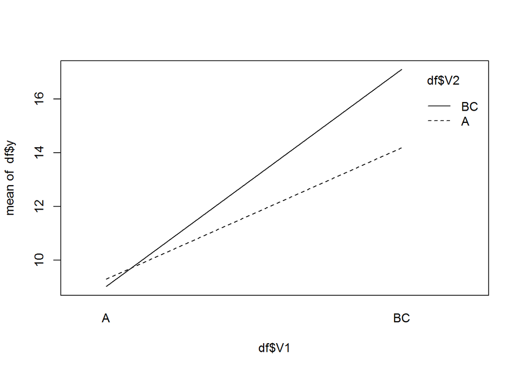

```r
df <- mutate(df, V1 = ifelse(V1 %in% c("B","C"), "BC", "A"))
df$V1 <- as.factor(df$V1)
df <- mutate(df, V2 = ifelse(V2 %in% c("B","C"), "BC", "A"))
df$V2 <- as.factor(df$V2)

interaction.plot(df$V1, df$V2, df$y)
```

```r
model2 <- lm(y~V1*V2, data=df)
summary(model2)
```

```
##
## Call:
## lm(formula = y ~ V1 * V2, data = df)
##
## Residuals:
##      Min       1Q   Median       3Q      Max
## -17.8502  -7.9669  -0.3974   7.0425  26.9242
##
## Coefficients:
##             Estimate Std. Error t value Pr(>|t|)
## (Intercept)   9.2892     1.6051   5.787 1.82e-08 ***
## V1BC          4.9055     2.0385   2.406   0.0167 *
## V2BC         -0.2713     2.0385  -0.133   0.8942
## V1BC:V2BC     3.1809     2.5386   1.253   0.2112
## ---
## Signif. codes:  0 '***' 0.001 '**' 0.01 '*' 0.05 '.' 0.1 ' ' 1
##
## Residual standard error: 9.895 on 296 degrees of freedom
## Multiple R-squared:  0.1134, Adjusted R-squared:  0.1044
## F-statistic: 12.62 on 3 and 296 DF,  p-value: 8.716e-08
```

```r
(a2 <- anova(model2))
```

```
## Analysis of Variance Table
##
## Response: y
##            Df  Sum Sq Mean Sq F value    Pr(>F)
## V1          1  3343.0  3343.0 34.1446 1.348e-08 ***
## V2          1   210.2   210.2  2.1468    0.1439
## V1:V2       1   153.7   153.7  1.5701    0.2112
## Residuals 296 28980.5    97.9
## ---
## Signif. codes:  0 '***' 0.001 '**' 0.01 '*' 0.05 '.' 0.1 ' ' 1
```

Interakcje nie zachodzą.

3. Dla zmiennej `V1` porĂłwnaj wyniki dla rĂłĹĽnych kontrastĂłw, przynajmniej Helmerta, poly i sum.

```r
model3 <- lm(y~V1, data=df, contrasts=list(V1=contr.helmert(2)))
summary(model3)
```

```
##
## Call:
## lm(formula = y ~ V1, data = df, contrasts = list(V1 = contr.helmert(2)))
##
## Residuals:
##      Min       1Q   Median       3Q      Max
## -16.9483  -8.0708  -0.4626   6.8113  26.1414
##
## Coefficients:
##             Estimate Std. Error t value Pr(>|t|)
## (Intercept)  12.6617     0.6077  20.836  < 2e-16 ***
## V11           3.5407     0.6077   5.827 1.47e-08 ***
## ---
## Signif. codes:  0 '***' 0.001 '**' 0.01 '*' 0.05 '.' 0.1 ' ' 1
##
## Residual standard error: 9.923 on 298 degrees of freedom
## Multiple R-squared:  0.1023, Adjusted R-squared:  0.09926
## F-statistic: 33.95 on 1 and 298 DF,  p-value: 1.466e-08
```

```r
model4 <- lm(y~V1, data=df, contrasts=list(V1=contr.poly(2)))
summary(model4)
```

```
##
## Call:
## lm(formula = y ~ V1, data = df, contrasts = list(V1 = contr.poly(2)))
##
## Residuals:
##      Min       1Q   Median       3Q      Max
## -16.9483  -8.0708  -0.4626   6.8113  26.1414
##
## Coefficients:
##             Estimate Std. Error t value Pr(>|t|)
## (Intercept)  12.6617     0.6077  20.836  < 2e-16 ***
## V1.L          5.0072     0.8594   5.827 1.47e-08 ***
## ---
## Signif. codes:  0 '***' 0.001 '**' 0.01 '*' 0.05 '.' 0.1 ' ' 1
##
## Residual standard error: 9.923 on 298 degrees of freedom
## Multiple R-squared:  0.1023, Adjusted R-squared:  0.09926
## F-statistic: 33.95 on 1 and 298 DF,  p-value: 1.466e-08
```

```r
model5 <- lm(y~V1, data=df, contrasts=list(V1=contr.sum(2)))
summary(model5)
```

```
##
## Call:
## lm(formula = y ~ V1, data = df, contrasts = list(V1 = contr.sum(2)))
##
## Residuals:
##      Min       1Q   Median       3Q      Max
## -16.9483  -8.0708  -0.4626   6.8113  26.1414
##
## Coefficients:
##             Estimate Std. Error t value Pr(>|t|)
## (Intercept)  12.6617     0.6077  20.836  < 2e-16 ***
## V11          -3.5407     0.6077  -5.827 1.47e-08 ***
## ---
## Signif. codes:  0 '***' 0.001 '**' 0.01 '*' 0.05 '.' 0.1 ' ' 1
##
## Residual standard error: 9.923 on 298 degrees of freedom
## Multiple R-squared:  0.1023, Adjusted R-squared:  0.09926
## F-statistic: 33.95 on 1 and 298 DF,  p-value: 1.466e-08
```

Wszystkie kontrasty pokazujÄ… istotnoĹ›Ä‡ kolejnych grup referencyjnych.

4. Wykonaj test post hoc dla zmiennej `V3`. KtĂłre poziomy rĂłĹĽniÄ… siÄ™ pomiÄ™dzy sobÄ…?

```r
(t6 <- TukeyHSD(aov(y~V3, data=df)))
```

```
##   Tukey multiple comparisons of means
##     95% family-wise confidence level
##
## Fit: aov(formula = y ~ V3, data = df)
##
## $V3
##            diff        lwr       upr     p adj
## B-A -3.39017450 -12.017339  5.236990 0.9628223
## C-A -2.89937954 -11.526544  5.727785 0.9870366
## D-A -2.24703182 -10.874197  6.380133 0.9980538
## E-A -0.95545573  -9.582620  7.671709 0.9999985
## F-A -2.22425035 -10.851415  6.402914 0.9982024
## G-A -2.45252224 -11.079687  6.174642 0.9961900
## H-A  0.91048096  -7.716684  9.537646 0.9999990
## I-A -2.41530762 -11.042472  6.211857 0.9966072
## J-A -5.37780218 -14.004967  3.249362 0.6084554
## C-B  0.49079496  -8.136370  9.117960 1.0000000
## D-B  1.14314267  -7.484022  9.770307 0.9999930
## E-B  2.43471877  -6.192446 11.061883 0.9963945
## F-B  1.16592415  -7.461241  9.793089 0.9999917
## G-B  0.93765226  -7.689512  9.564817 0.9999988
## H-B  4.30065545  -4.326509 12.927820 0.8524088
## I-B  0.97486688  -7.652298  9.602032 0.9999982
## J-B -1.98762769 -10.614792  6.639537 0.9992629
## D-C  0.65234771  -7.974817  9.279512 0.9999999
## E-C  1.94392381  -6.683241 10.571088 0.9993838
## F-C  0.67512919  -7.952035  9.302294 0.9999999
## G-C  0.44685730  -8.180307  9.074022 1.0000000
## H-C  3.80986050  -4.817304 12.437025 0.9240263
## I-C  0.48407192  -8.143093  9.111237 1.0000000
## J-C -2.47842265 -11.105587  6.148742 0.9958755
## E-D  1.29157610  -7.335589  9.918741 0.9999798
## F-D  0.02278148  -8.604383  8.649946 1.0000000
## G-D -0.20549042  -8.832655  8.421674 1.0000000
## H-D  3.15751278  -5.469652 11.784677 0.9766853
## I-D -0.16827579  -8.795440  8.458889 1.0000000
## J-D -3.13077036 -11.757935  5.496394 0.9779828
## F-E -1.26879462  -9.895959  7.358370 0.9999827
## G-E -1.49706651 -10.124231  7.130098 0.9999291
## H-E  1.86593668  -6.761228 10.493101 0.9995580
## I-E -1.45985189 -10.087017  7.167313 0.9999427
## J-E -4.42234646 -13.049511  4.204818 0.8301707
## G-F -0.22827189  -8.855437  8.398893 1.0000000
## H-F  3.13473131  -5.492433 11.761896 0.9777941
## I-F -0.19105727  -8.818222  8.436107 1.0000000
## J-F -3.15355184 -11.780717  5.473613 0.9768810
## H-G  3.36300320  -5.264161 11.990168 0.9646955
## I-G  0.03721462  -8.589950  8.664379 1.0000000
## J-G -2.92527994 -11.552445  5.701885 0.9862008
## I-H -3.32578857 -11.952953  5.301376 0.9671471
## J-H -6.28828314 -14.915448  2.338882 0.3766477
## J-I -2.96249457 -11.589659  5.664670 0.9849265
```

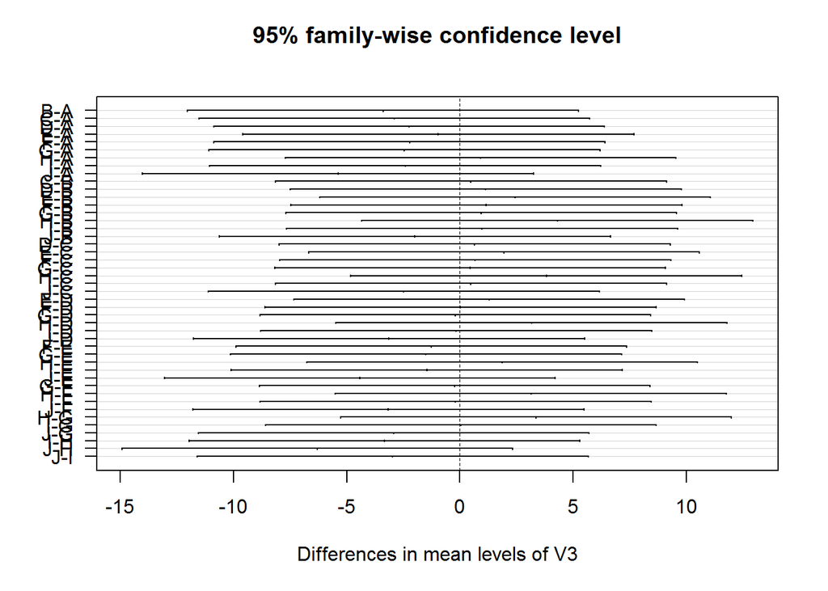

```r
plot(t6, las=1)
```

Ĺ»adne poziomy nie rĂłĹĽniÄ… siÄ™ istotnie Ĺ›rednimi.

5. Zweryfikuj istotnoĹ›Ä‡ zaleĹĽnoĹ›ci od zmiennej `V4`

```r
model7 <- lm(y~V4, data=df)
summary(model7)
```

```
##
## Call:
## lm(formula = y ~ V4, data = df)
##
## Residuals:
##      Min       1Q   Median       3Q      Max
## -16.6935  -9.2155   0.5815   6.9727  27.5147
##
## Coefficients:
##             Estimate Std. Error t value Pr(>|t|)
## (Intercept)   12.042      1.179  10.214   <2e-16 ***
## V4             3.696      2.082   1.775   0.0768 .
## ---
## Signif. codes:  0 '***' 0.001 '**' 0.01 '*' 0.05 '.' 0.1 ' ' 1
##
## Residual standard error: 10.42 on 298 degrees of freedom
## Multiple R-squared:  0.01047,    Adjusted R-squared:  0.007146
## F-statistic: 3.152 on 1 and 298 DF,  p-value: 0.07685
```

Odrzucamy hipotezÄ™ o zaleĹĽnoĹ›ci od zmiennej V4.

6. Czy istotna jest interakcja pomiÄ™dzy V4 a V1? Jak pokazaÄ‡ tÄ™ zaleĹĽnoĹ›Ä‡.

```r
model8 <- lm(y~V4*V1, data=df)
summary(model8)
```

```
##
## Call:
## lm(formula = y ~ V4 * V1, data = df)
##
## Residuals:
##      Min       1Q   Median       3Q      Max
## -18.8421  -7.8404  -0.3577   6.5896  24.6408
##
## Coefficients:
##             Estimate Std. Error t value Pr(>|t|)
## (Intercept)   9.4336     2.0314   4.644 5.15e-06 ***
## V4           -0.6388     3.6297  -0.176   0.8604
## V1BC          4.0493     2.4317   1.665   0.0969 .
## V4:V1BC       6.2345     4.3222   1.442   0.1502
## ---
## Signif. codes:  0 '***' 0.001 '**' 0.01 '*' 0.05 '.' 0.1 ' ' 1
##
## Residual standard error: 9.862 on 296 degrees of freedom
## Multiple R-squared:  0.1193, Adjusted R-squared:  0.1104
## F-statistic: 13.36 on 3 and 296 DF,  p-value: 3.335e-08
```

```r
(a8 <- anova(model8))
```

```
## Analysis of Variance Table
##
## Response: y
##            Df  Sum Sq Mean Sq F value    Pr(>F)
## V4          1   342.1   342.1  3.5179    0.0617 .
## V1          1  3354.6  3354.6 34.4914 1.149e-08 ***
## V4:V1       1   202.4   202.4  2.0807    0.1502
## Residuals 296 28788.3    97.3
## ---
## Signif. codes:  0 '***' 0.001 '**' 0.01 '*' 0.05 '.' 0.1 ' ' 1
```

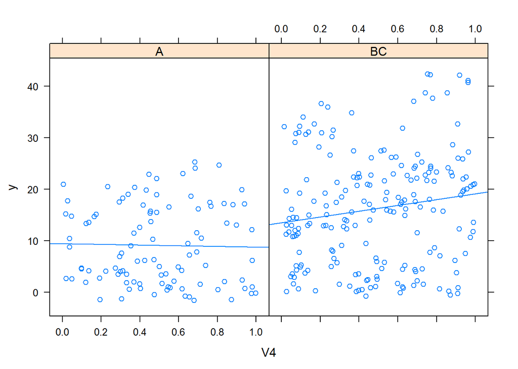

```r
xyplot(y~V4|V1, data=df, type=c("p","r"))
```

Interakcja nie jest istotna (pomimo tego, ĹĽe wykres sugeruje co innego).

7. Zweryfikuj zaleĹĽnoĹ›Ä‡ od zmiennej `V5`. A co jeĹĽeli ta zaleĹĽnoĹ›Ä‡ nie jest liniowa? SprawdĹş zaleĹĽnoĹ›Ä‡ od wielomianu stopnia 3.

```r
model9 <- lm(y~V5, data=df)
summary(model9)
```

```
##
## Call:
## lm(formula = y ~ V5, data = df)
##
## Residuals:
##     Min      1Q  Median      3Q     Max
## -15.380  -9.580  -0.122   7.444  29.076
##
## Coefficients:
##             Estimate Std. Error t value Pr(>|t|)
## (Intercept)  13.8584     0.6050  22.907   <2e-16 ***
## V5           -0.7885     1.3535  -0.583    0.561
## ---
## Signif. codes:  0 '***' 0.001 '**' 0.01 '*' 0.05 '.' 0.1 ' ' 1
##
## Residual standard error: 10.47 on 298 degrees of freedom
## Multiple R-squared:  0.001137,   Adjusted R-squared:  -0.002214
## F-statistic: 0.3393 on 1 and 298 DF,  p-value: 0.5607
```

```r
(a9 <- anova(model9))
```

```
## Analysis of Variance Table
##
## Response: y
##            Df Sum Sq Mean Sq F value Pr(>F)
## V5          1     37   37.18  0.3393 0.5607
## Residuals 298  32650  109.56
```

ZaleĹĽnoĹ›Ä‡ liniowa nie jest istotna. Sprawdzimy zaleĹĽnoĹ›Ä‡ od wielomianu stopnia 3.

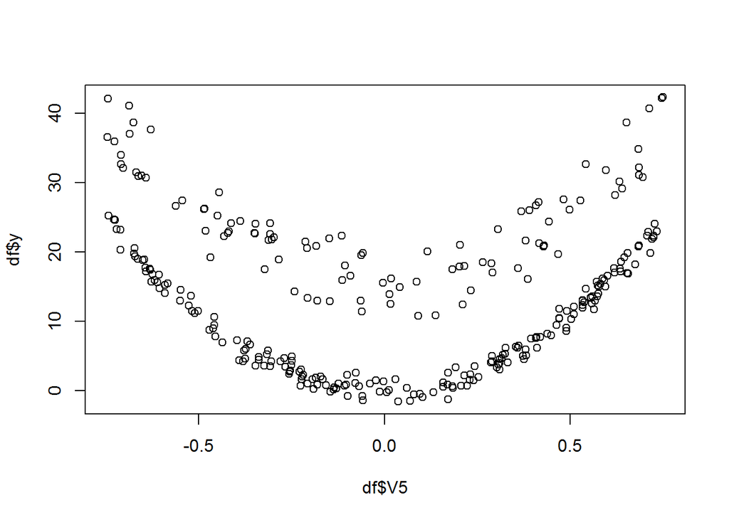

```r
plot(df$V5, df$y)
```

```r
model10 <- lm(y~poly(V5,3), data=df)
summary(model10)
```

```
##
## Call:
## lm(formula = y ~ poly(V5, 3), data = df)
##
## Residuals:
##    Min     1Q Median     3Q    Max
## -8.176 -5.598 -4.141  7.145 16.273
##
## Coefficients:
##              Estimate Std. Error t value Pr(>|t|)
## (Intercept)    13.842      0.436  31.747   <2e-16 ***
## poly(V5, 3)1   -6.098      7.552  -0.807    0.420
## poly(V5, 3)2  125.549      7.552  16.625   <2e-16 ***
## poly(V5, 3)3    2.572      7.552   0.341    0.734
## ---
## Signif. codes:  0 '***' 0.001 '**' 0.01 '*' 0.05 '.' 0.1 ' ' 1
##
## Residual standard error: 7.552 on 296 degrees of freedom
## Multiple R-squared:  0.4836, Adjusted R-squared:  0.4783
## F-statistic: 92.39 on 3 and 296 DF,  p-value: < 2.2e-16
```

```r
(a10 <- anova(model10))
```

```
## Analysis of Variance Table
##
## Response: y
##              Df Sum Sq Mean Sq F value    Pr(>F)
## poly(V5, 3)   3  15806  5268.8  92.386 < 2.2e-16 ***
## Residuals   296  16881    57.0
## ---
## Signif. codes:  0 '***' 0.001 '**' 0.01 '*' 0.05 '.' 0.1 ' ' 1
```

8. Zbuduj nowÄ… zmiennÄ… `NV := V4 - 2*V5`. Zbadaj zwiÄ…zek z tÄ… zmiennÄ….

```r
df <- mutate(df, NV=V4-2*V5)
model11 <- lm(y~NV, data=df)
summary(model11)
```

```
##
## Call:
## lm(formula = y ~ NV, data = df)
##
## Residuals:
##      Min       1Q   Median       3Q      Max
## -15.5025  -9.6155   0.1225   7.2724  29.3224
##
## Coefficients:
##             Estimate Std. Error t value Pr(>|t|)
## (Intercept)  13.5348     0.6665  20.309   <2e-16 ***
## NV            0.6897     0.6350   1.086    0.278
## ---
## Signif. codes:  0 '***' 0.001 '**' 0.01 '*' 0.05 '.' 0.1 ' ' 1
##
## Residual standard error: 10.45 on 298 degrees of freedom
## Multiple R-squared:  0.003943,   Adjusted R-squared:  0.0006007
## F-statistic:  1.18 on 1 and 298 DF,  p-value: 0.2783
```

```r
(a11 <- anova(model11))
```

```
## Analysis of Variance Table
##
## Response: y
##            Df Sum Sq Mean Sq F value Pr(>F)
## NV          1    129  128.89  1.1797 0.2783
## Residuals 298  32558  109.26
```

ZaleĹĽnoĹ›Ä‡ nie jest istotna.

9. Wybierz model optymalny wedĹ‚ug kryterium BIC - zrĂłb przeglÄ…d peĹ‚ny wszystkich modeli.

```r
zm <- colnames(df)[2:12]
wsp = (bincombinations(length(zm))==1)[-1,]
params = matrix(0, nrow(wsp), 4)
for (i in 1:nrow(wsp)) {
     form = as.formula(paste("y~", paste(zm[wsp[i,]], collapse="+")))
     model12 = lm(form, data=df)
     params[i,1] = AIC(model12, k=log(nrow(df)))
     params[i,2] = model12$rank
     params[i,3] = summary(model12)$adj.r.squared
     params[i,4] = AIC(model12)
}
params <- as.data.frame(params)
colnames(params) <- c("BIC", "rank", "adjR2", "AIC")
head(params)
```

```
##        BIC rank         adjR2      AIC
## 1 2274.578    2  0.0006007208 2263.466
## 2 2273.661    2  0.0036490405 2262.550
## 3 2278.178    3  0.0042408754 2263.363
## 4 2275.327    2 -0.0018993471 2264.216
## 5 2279.991    3 -0.0017926949 2265.176
## 6 2279.020    3  0.0014440809 2264.205
```

Model optymalny według kryterium BIC:

```r
as.formula(paste("y~",paste(zm[wsp[which.min(params$BIC),]], collapse="+")))
```

```
## y ~ V1
```

10. Wybierz model optymalny wedĹ‚ug kryterium AIC - uĹĽyj funkcji step.

```r
tmpFun = function(fit, aic) {
     list(size = length(fit$coefficients), aic = aic, likelihood = logLik(fit))
}

 model13 = step(lm(y~., data=df), k=2, keep=tmpFun, trace=0)

 kolumny = colnames(df)[2:12]
 maxModel = as.formula(paste("~",paste(kolumny,collapse="+")))

# od modelu pustego do optymalnego
model14 = step(lm(y~1, data=df), scope=list(upper = maxModel, lower = ~1), direction ="forward", k=2, keep=tmpFun, trace=0)

# od wybranego modelu do optymalnego
model15 = step(lm(y~V1+V4, data=df), scope=list(upper = maxModel, lower = ~1), k=2, keep=tmpFun, trace=0)

model15$keep
```

```
##            [,1]      [,2]
## size       3         4
## aic        1377.284  1376.766
## likelihood -1111.324 -1110.065
```

Narysujmy ścieżki.

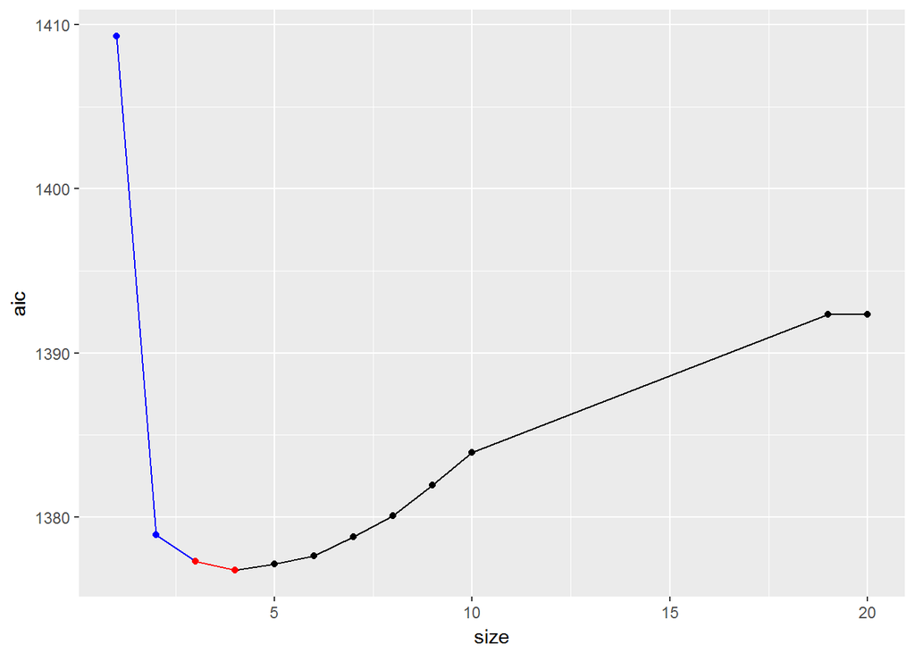

```r
getMD <- function(md) {
  data.frame(size = unlist(apply(md, 2, `[`, 1)),
             aic = unlist(apply(md, 2, `[`, 2)))
}

df1 <- getMD(model13$keep)
df2 <- getMD(model14$keep)
df4 <- getMD(model15$keep)

pl <- ggplot() +
  geom_point(data=df1, aes(size, aic)) +
  geom_line(data=df1, aes(size, aic)) +
  geom_point(data=df2, aes(size, aic), color="blue") +
  geom_line(data=df2, aes(size, aic), color="blue") +
  geom_point(data=df4, aes(size, aic), color="red")  +
  geom_line(data=df4, aes(size, aic), color="red")

pl
```

[figure not shown]

```r
pl + xlim(15,25) + ylim(-4780, -4750)
```

Jak widać metodą step otrzymujemy tu ten sam model, bez względu na to czy startujemy z modelu pustego, pełnego czy wybranego. Jest to model:

```r
model13
```

```
##
## Call:
## lm(formula = y ~ V1 + V4 + V7, data = df)
##
## Coefficients:
## (Intercept)         V1BC           V4           V7
##      8.2456       7.2419       3.4703      -0.9293
```

```r
model14
```

```
##
## Call:
## lm(formula = y ~ V1 + V4 + V7, data = df)
##
## Coefficients:
## (Intercept)         V1BC           V4           V7
##      8.2456       7.2419       3.4703      -0.9293
```

```r
model15
```

```
##
## Call:
## lm(formula = y ~ V1 + V4 + V7, data = df)
##
## Coefficients:
## (Intercept)         V1BC           V4           V7
##      8.2456       7.2419       3.4703      -0.9293
```

11. Wykonaj diagnostykÄ™ reszt. Czy sÄ… obserwacje odstajÄ…ce/wpĹ‚ywowe?

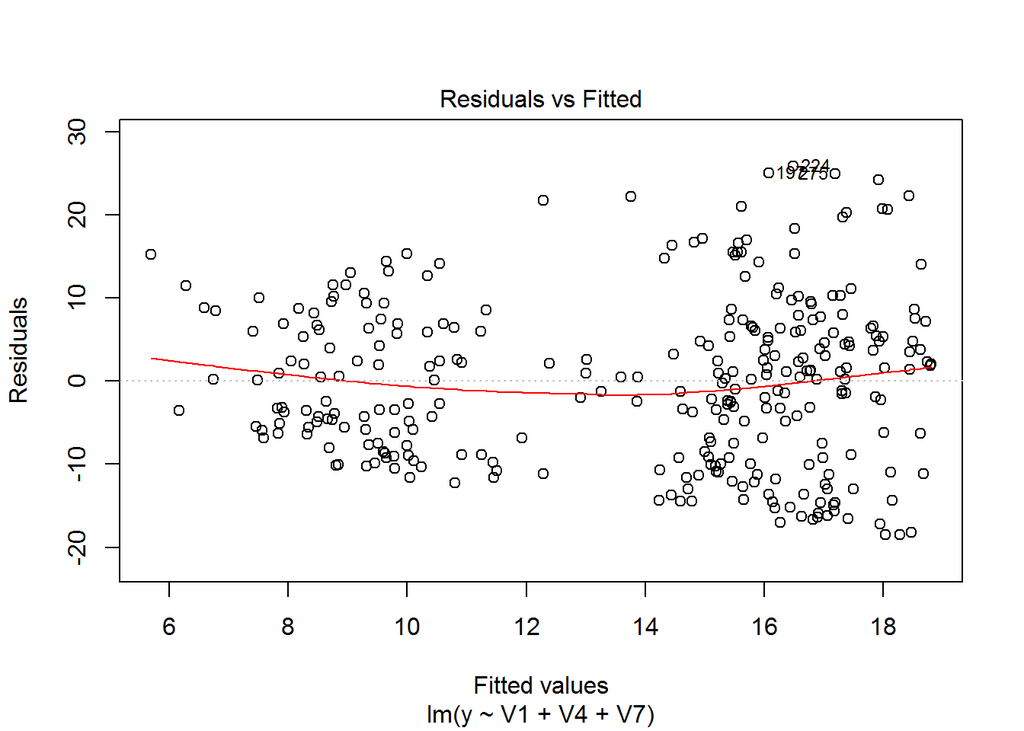

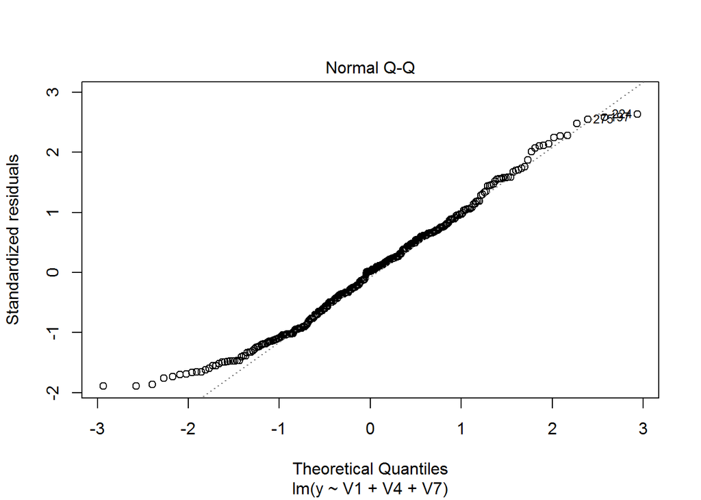

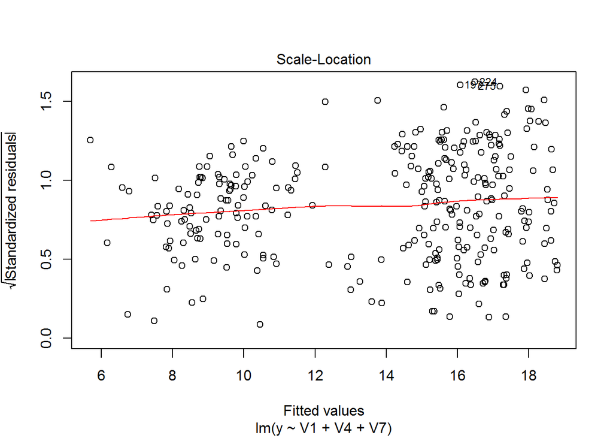

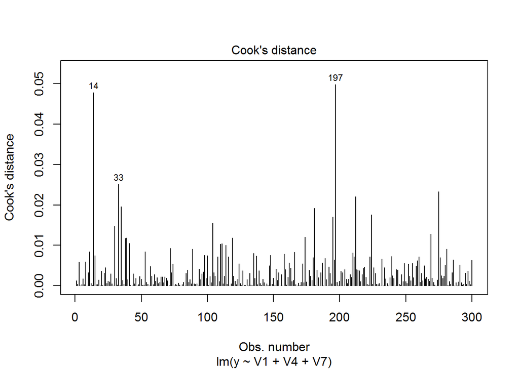

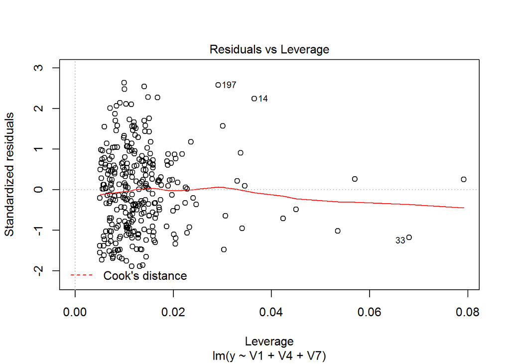

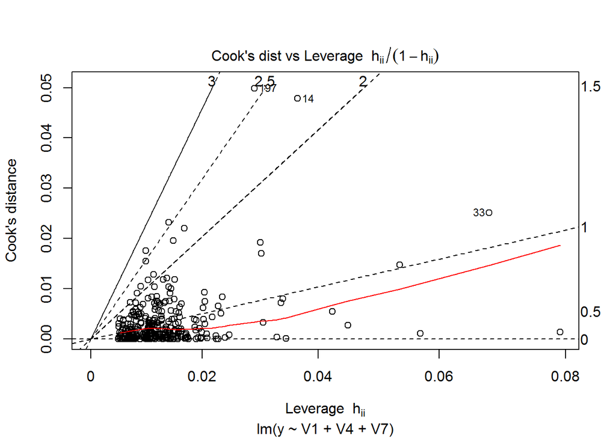

```r
plot(model15, which=1:6)
```

```r
bptest(model15)
```

```
##
##  studentized Breusch-Pagan test
##
## data:  model15
## BP = 16.295, df = 3, p-value = 0.0009866
```

Residuals vs Fitted: Reszty nie zależą wyraźnie od zmiennej objaśnianej. Wynik pozytywny.

Normal Q-Q: Kwantyle układają się z grubsza wzdłuż przekątnej. Pewien problem z lewym ogonem. Wynik neutralny.

Scale Location: Wariancja reszt nie zależy istotnie od zmiennej objaśnianej. Wynik pozytywny.

Residuals vs Leverage: Nie widzimy obserwacji o bardzo odstającej dźwigni. Wynik pozytywny.

Cook’s distance: Wszystkie obserwacje są typowe, miara Cook’a poniżej 1. Wynik pozytywny.

Cook’s dist vs Leverage: Raczej nie ma obserwacji bardzo wpływowych. Wynik pozytywny.

bptest: Wariancje reszt nie są jednorodne. Wynik negatywny.

12. Zweryfikuj istotnoĹ›Ä‡ interakcji `V6` i `V7`.

```r
model16 <- lm(y~V6:V7, data=df)
summary(model16)
```

```
##
## Call:
## lm(formula = y ~ V6:V7, data = df)
##
## Residuals:
##      Min       1Q   Median       3Q      Max
## -15.6589  -9.6432  -0.4315   6.9396  28.9080
##
## Coefficients:
##             Estimate Std. Error t value Pr(>|t|)
## (Intercept)  14.1862     0.7030  20.179   <2e-16 ***
## V6:V7        -0.3909     0.4090  -0.956     0.34
## ---
## Signif. codes:  0 '***' 0.001 '**' 0.01 '*' 0.05 '.' 0.1 ' ' 1
##
## Residual standard error: 10.46 on 298 degrees of freedom
## Multiple R-squared:  0.003056,   Adjusted R-squared:  -0.0002898
## F-statistic: 0.9134 on 1 and 298 DF,  p-value: 0.34
```

```r
(a16 <- anova(model16))
```

```
## Analysis of Variance Table
##
## Response: y
##            Df Sum Sq Mean Sq F value Pr(>F)
## V6:V7       1    100  99.881  0.9134   0.34
## Residuals 298  32588 109.354
```

Interakcje te nie są istotne.

13. PorĂłwnaj wyniki z wynikami funkcji `ctree` pakiet `partykit`.

```r
(r17 <- ctree(y~., data=df))
```

```
##
## Model formula:
## y ~ V1 + V2 + V3 + V4 + V5 + V6 + V7 + V8 + V9 + V10 + NV
##
## Fitted party:
## [1] root
## |   [2] V1 in A: 9.121 (n = 100, err = 5829.2)
## |   [3] V1 in BC: 16.202 (n = 200, err = 23515.1)
##
## Number of inner nodes:    1
## Number of terminal nodes: 2
```

14. UĹĽyj funkcji `optim()` aby znaleĹşÄ‡ oceny wspĂłĹ‚czynnikĂłw z kryterium do optymalizacji `abs(y - Xb)`
15. Funkcja `rlm` z pakietu `MASS` wykonuje regresjÄ™ odpornÄ…. SprawdĹş jak wpĹ‚ynie ona na ocenÄ™ wspĂłĹ‚czynnikĂłw.